# Taller ABC Invesitgación - OLS

Politai

Chiara Zamora y Alexander Benites

Febrero 2024

```r
library(rio)
library(reshape2)
library(stringr)
library(ggthemes)
library(dplyr)
```

### 1. Limpieza y tratamiento de datos:

#### 1.1. Limpieza y tratamiento de la base de resultados electorales (variable dependiente)

Apertura:

```r
segunda_vuelta = import("https://github.com/ChiaraZamoraM/ABCInvestiga/raw/main/data/votacion-distrito-resultados.csv")
ubigeos = import("https://github.com/ChiaraZamoraM/ABCInvestiga/raw/main/data/votacion-distrito-resumen.csv") #Para incluir UBIGEO RENIEC
equivalencias = import("https://github.com/ChiaraZamoraM/ABCInvestiga/raw/main/data/Equivalencias.xlsx") #Para incluir UBIGEO INEI
```

Nos quedamos con algunos vectores de interés de la base de resultados electorales:

- Departamento
- Provincia
- Distrito
- Agrupación
- Total de votos válidos
- % de votos emitidos.

```r
data = segunda_vuelta[,c(1:3,5,6,7)]
head(data)
```

```
##   departamento provincia  distrito                           AGRUPACION
## 1     AYACUCHO    HUANTA AYAHUANCO PARTIDO POLITICO NACIONAL PERU LIBRE
## 2     AYACUCHO    HUANTA AYAHUANCO                       FUERZA POPULAR
## 3     AYACUCHO    HUANTA     SIVIA PARTIDO POLITICO NACIONAL PERU LIBRE
## 4     AYACUCHO    HUANTA     SIVIA                       FUERZA POPULAR
## 5     AYACUCHO    HUANTA LLOCHEGUA PARTIDO POLITICO NACIONAL PERU LIBRE
## 6     AYACUCHO    HUANTA LLOCHEGUA                       FUERZA POPULAR
##   TOTAL_VOTOS POR_VALIDOS
## 1         664      87.025
## 2          99      12.975
## 3        4174      85.832
## 4         689      14.168
## 5        3664      91.122
## 6         357       8.878
```

La estructura que manejamos no ayuda para hacer el análisis. ¿Por qué?

```r
#De columnas a filas:
data=reshape(data, direction="wide", idvar=c("departamento", "provincia","distrito"), timevar="AGRUPACION")
head(data)
```

```
##    departamento provincia  distrito
## 1      AYACUCHO    HUANTA AYAHUANCO
## 3      AYACUCHO    HUANTA     SIVIA
## 5      AYACUCHO    HUANTA LLOCHEGUA
## 7      AYACUCHO    HUANTA   CANAYRE
## 9      AYACUCHO    HUANTA PUCACOLPA
## 11     AYACUCHO    LA MAR      AYNA
##    TOTAL_VOTOS.PARTIDO POLITICO NACIONAL PERU LIBRE
## 1                                               664
## 3                                              4174
## 5                                              3664
## 7                                              1309
## 9                                               801
## 11                                             3767
##    POR_VALIDOS.PARTIDO POLITICO NACIONAL PERU LIBRE TOTAL_VOTOS.FUERZA POPULAR
## 1                                            87.025                         99
## 3                                            85.832                        689
## 5                                            91.122                        357
## 7                                            93.167                         96
## 9                                            90.304                         86
## 11                                           75.431                       1227
##    POR_VALIDOS.FUERZA POPULAR
## 1                      12.975
## 3                      14.168
## 5                       8.878
## 7                       6.833
## 9                       9.696
## 11                     24.569
```

Cambiamos los nombres:

```r
colnames(data) = c("DEPA","PROV","DIST","VOT_PL","PORC_PL","VOT_FP","PORC_FP")
```

Otro GRAN problema: no tenemos los ubigeos en la base de datos. Sin eso, manipular o agregar información va a ser muy complicado. Vamos a tener que improvisar.

```r
#Consiguiendo identificación por ubigeos:
data$id = paste0(data$DEPA,data$PROV)
data$id= paste0(data$id,data$DIST)

ubigeos$id = paste0(ubigeos$departamento,ubigeos$provincia)
ubigeos$id = paste0(ubigeos$id,ubigeos$distrito)
```

Veamos cómo queda nuestro vector de unificación en cada base de datos:

```r
rownames(data) = NULL #Restauramos el número de cada fila
data[1696,8]
```

```
## [1] "AMAZONASCHACHAPOYASCHACHAPOYAS"
```

Esto se parece más a un vector único

```r
ubigeos[1,33]
```

```
## [1] "AMAZONASCHACHAPOYASCHACHAPOYAS"
```

Nos quedamos con las variables que nos interesan:

```r
ubigeos = ubigeos[,c(4,33)]
```

Eliminamos espacios en blanco, ya que tenemos este problema:

```r
ubigeos[1488,2]
```

```
## [1] "LORETODATEM DEL MARAÑONBARRANCA"
```

```r
data[32,8]
```

```
## [1] "LORETODATEM DEL MARAÑONBARRANCA"
```

Los espacios en blanco ya son, para R, una diferencia entre ambas celdas y las toma como diferentes. Solucionemos el problema eliminando los espacios en blanco.

```r
ubigeos$id=gsub(" ","",ubigeos$id) #De los ubigeos
data$id=gsub(" ","",data$id) #De la base de resultados electorales
```

Verificamos:

```r
ubigeos[1488,2]
```

```
## [1] "LORETODATEMDELMARAÑONBARRANCA"
```

```r
data[32,8]
```

```
## [1] "LORETODATEMDELMARAÑONBARRANCA"
```

Hemos verificado que todo está sin tildes y en mayúsculas, así que no tendremos ningún trabajo de limpieza sobre ambos puntos.

Ahora si podemos unificar nuestras bases:

```r
data = merge(data,ubigeos, by = "id")
data = data[,c(2:9)]
```

Hasta aquí tenemos una base con lo siguiente:

- Departamento, Provincia y Distrito
- Resultados electorales de FP y PL
- UBIGEO RENIEC

```r
head(data)
```

```
##       DEPA  PROV     DIST VOT_PL PORC_PL VOT_FP PORC_FP CCODI_UBIGEO
## 1 AMAZONAS BAGUA ARAMANGO   3243  65.107   1738  34.893        10202
## 2 AMAZONAS BAGUA    BAGUA   7623  59.709   5144  40.291        10205
## 3 AMAZONAS BAGUA COPALLIN   1940  69.113    867  30.887        10203
## 4 AMAZONAS BAGUA EL PARCO    690  73.404    250  26.596        10204
## 5 AMAZONAS BAGUA    IMAZA   8706  90.669    896   9.331        10206
## 6 AMAZONAS BAGUA  LA PECA   2769  62.016   1696  37.984        10201
```

Sin embargo, si queremos agregar otros indicadores sociodemográficos, probablemente el código de identificación de cada unidad territorial sea el UBIGEO INEI. Para eso hemos cargado una tabla de equivalencias:

```r
#Nos quedamos con las columnas de interés: los dos ubigeos
equivalencias = equivalencias[,c(1,2)]
```

Ya tenemos nuestro vector de equivalencias. Ahora, veamos nuestro UBIGEO RENIEC en la base de resultados electorales:

```r
data[1,8]
```

```
## [1] 10202
```

Le falta un cero, hay que agregarlo:

```r
#Falta un 0
data$CCODI_UBIGEO=str_pad(data$CCODI_UBIGEO, 6, pad = "0")
```

Listo!

```r
data[1,8]
```

```
## [1] "010202"
```

Unificamos los ubigeos:

```r
data = merge(data,equivalencias, by.x = "CCODI_UBIGEO", by.y = "UBIGEO_RENIEC", all.x = T)
```

Veamos nuestra data:

```r
head(data)
```

[output not shown]

#### 1.2. Limpieza y tratamiento de la base de indicadores sociodemográficos (variables independientes)

```r
ceplan = import("https://github.com/ChiaraZamoraM/ABCInvestiga/raw/main/data/ceplan.xlsx")
indig = import("https://github.com/ChiaraZamoraM/ABCInvestiga/raw/main/data/indig.xlsx")
```

Veamos cómo se encuentran nuestros datos en la base del CEPLAN

```r
head(ceplan)
```

```
##           ...1 Perú: datos para el planeamiento estratégico, distrital.
## 1         <NA>                                                     <NA>
## 2         <NA>                                                     <NA>
## 3         <NA>                                                   Ubigeo
## 4     Nacional                                                 NACIONAL
## 5 Nacional_esp                            NACIONAL SIN LA PROV. DE LIMA
## 6       Región                                                   150000
##                                  ...3                             ...4
## 1                                <NA>                             <NA>
## 2                                <NA>                        POBLACIÓN
## 3 Región /\r\nProvincia /\r\nDistrito Población total\r\n(2007)\r\n1a/
## 4                                <NA>                         28481901
## 5                                <NA>                         20620156
## 6                                LIMA                          8730820
##                               ...5                             ...6
```

[output cut: 230 more lines]

```r
tail(ceplan)
```

```
##      ...1 Perú: datos para el planeamiento estratégico, distrital.         ...3
## 2128 <NA>                                                     <NA>     DISTRITO
## 2129 <NA>                                                     <NA>         <NA>
## 2130 <NA>                                                     <NA>     ZONA SUR
## 2131 <NA>                                                     <NA> DEPARTAMENTO
## 2132 <NA>                                                     <NA>    PROVINCIA
## 2133 <NA>                                                     <NA>     DISTRITO
##      ...4 ...5 ...6 ...7 ...8 ...9 ...10 ...11 ...12 ...13 ...14 ...15 ...16
## 2128 <NA> <NA> <NA> <NA> <NA> <NA>  <NA>  <NA>  <NA>  <NA>  <NA>  <NA>  <NA>
## 2129 <NA> <NA> <NA> <NA> <NA> <NA>  <NA>  <NA>  <NA>  <NA>  <NA>  <NA>  <NA>
## 2130 <NA> <NA> <NA> <NA> <NA> <NA>  <NA>  <NA>  <NA>  <NA>  <NA>  <NA>  <NA>
## 2131 <NA> <NA> <NA> <NA> <NA> <NA>  <NA>  <NA>  <NA>  <NA>  <NA>  <NA>  <NA>
## 2132 <NA> <NA> <NA> <NA> <NA> <NA>  <NA>  <NA>  <NA>  <NA>  <NA>  <NA>  <NA>
## 2133 <NA> <NA> <NA> <NA> <NA> <NA>  <NA>  <NA>  <NA>  <NA>  <NA>  <NA>  <NA>
##      ...17 ...18 ...19 ...20 ...21 ...22 ...23 ...24 ...25 ...26 ...27 ...28
```

[output cut: 20 more lines]

De esta base, queremos lo siguiente:

- Tipo (1)
- UBIGEO (2)
- Población al 2020 (6)
- Población con alguna discapacidad al 2020 (9)
- Porcentaje de desnutrición (30)
- Porcentaje de población en situación de pobreza (40)
- Gasto presupuestal per capita en soles (48)

Empecemos a limpiar un poco. Por lo pronto, queremos solo los distritos

```r
ceplan = ceplan %>%
  select(c(1,2,6,9,30,40,48)) #Nos quedamos con algunas columnas

colnames(ceplan) = c("CAT","UBIGEO","POB_2020","DISC_2020","DESNUTRICION","POBREZA","GASTO") #Cambiamos los nombres de las columnas

ceplan = ceplan %>%
  filter(CAT == "Distrito") #Filtramos por distritos
```

Volvemos los vectores numéricos:

```r
ceplan$POB_2020 = as.numeric(ceplan$POB_2020)
ceplan$DISC_2020 = as.numeric(ceplan$DISC_2020)
ceplan$POBREZA = as.numeric(ceplan$POBREZA)
ceplan$DESNUTRICION = as.numeric(ceplan$DESNUTRICION)
ceplan$GASTO = as.numeric(ceplan$GASTO)

#Porcentaje de personas que cuentan con alguna discapacidad:
ceplan$DISC_2020_PORC = ceplan$DISC_2020/ceplan$POB_2020
ceplan$DISC_2020_PORC = ceplan$DISC_2020_PORC*100
```

Nos quedamos solo con los vectores de interés:

```r
ceplan = ceplan[,c(2,5:8)]
```

Juntamos la información:

```r
data = merge(data,ceplan, by.x = "UBIGEO_INEI", by.y = "UBIGEO", all.x = T)
```

Finalmente:

```r
indig$TASA_INDIGENA = indig$TASA_INDIGENA*100
data = merge(data, indig, by.x = "UBIGEO_INEI", by.y = "UBIGEO", all.x = T)
```

### OLS

Imaginemos que la hipótesis que tenemos es que el porcentaje de personas que se autoidentifican como indígenas explica el voto por Pedro Castillo en la segunda vuelta de las EG 2021. Probemos eso con un modelo.

Primero veamos si las variables se encuentran asociadas:

```r
library(PerformanceAnalytics)
```

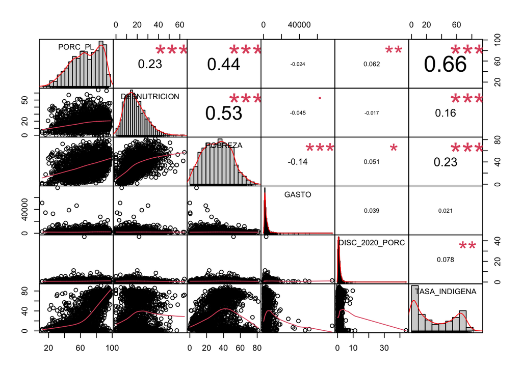

```r
chart.Correlation(data[,c(7,10,11,12,13,14)], histogram=TRUE, pch=19)
```

Pongamos esto a prueba en un modelo:

```r
modelo1 = lm(PORC_PL ~ TASA_INDIGENA, data = data)
summary(modelo1)
```

```
##
## Call:
## lm(formula = PORC_PL ~ TASA_INDIGENA, data = data)
##
## Residuals:
##     Min      1Q  Median      3Q     Max
## -53.889  -8.794   1.709   9.070  44.688
##
## Coefficients:
##               Estimate Std. Error t value Pr(>|t|)
## (Intercept)   53.11592    0.51136  103.87   <2e-16 ***
## TASA_INDIGENA  0.43284    0.01164   37.18   <2e-16 ***
## ---
## Signif. codes:  0 '***' 0.001 '**' 0.01 '*' 0.05 '.' 0.1 ' ' 1
##
## Residual standard error: 14.45 on 1819 degrees of freedom
##   (53 observations deleted due to missingness)
## Multiple R-squared:  0.4318, Adjusted R-squared:  0.4315
## F-statistic:  1382 on 1 and 1819 DF,  p-value: < 2.2e-16
```

Exploremos las predicciones del modelo 1:

```r
library(ggeffects)
ggpredict(modelo1)
```

```
## $TASA_INDIGENA
## # Predicted values of PORC_PL
##
## TASA_INDIGENA | Predicted |         95% CI
## ------------------------------------------
##             0 |     53.12 | [52.11, 54.12]
##            20 |     61.77 | [61.05, 62.50]
##            40 |     70.43 | [69.75, 71.11]
##            60 |     79.09 | [78.18, 79.99]
##            80 |     87.74 | [86.48, 89.01]
##           100 |     96.40 | [94.73, 98.07]
##
## attr(,"class")
## [1] "ggalleffects" "list"
## attr(,"model.name")
## [1] "modelo1"
```

Vamos a controlar esta hipótesis por las otras variables:

```r
modelo2 = lm(PORC_PL ~ TASA_INDIGENA + DESNUTRICION + DISC_2020_PORC + POBREZA + GASTO,
             data = data)
summary(modelo2)
```

```
##
## Call:
## lm(formula = PORC_PL ~ TASA_INDIGENA + DESNUTRICION + DISC_2020_PORC +
##     POBREZA + GASTO, data = data)
##
## Residuals:
##     Min      1Q  Median      3Q     Max
## -57.865  -7.543   1.157   8.532  37.692
##
## Coefficients:
##                  Estimate Std. Error t value Pr(>|t|)
## (Intercept)     4.239e+01  8.734e-01  48.534   <2e-16 ***
## TASA_INDIGENA   3.879e-01  1.118e-02  34.681   <2e-16 ***
## DESNUTRICION   -3.700e-02  3.855e-02  -0.960    0.337
## DISC_2020_PORC  1.048e-01  2.268e-01   0.462    0.644
## POBREZA         3.756e-01  2.275e-02  16.509   <2e-16 ***
## GASTO           1.378e-05  8.740e-05   0.158    0.875
## ---
## Signif. codes:  0 '***' 0.001 '**' 0.01 '*' 0.05 '.' 0.1 ' ' 1
##
## Residual standard error: 13 on 1685 degrees of freedom
##   (183 observations deleted due to missingness)
## Multiple R-squared:  0.5441, Adjusted R-squared:  0.5427
## F-statistic: 402.2 on 5 and 1685 DF,  p-value: < 2.2e-16
```

Veamos cómo se ve la formula y los coeficientes:

```r
modelo2$coefficients
```

```
##    (Intercept)  TASA_INDIGENA   DESNUTRICION DISC_2020_PORC        POBREZA
##   4.239025e+01   3.878809e-01  -3.699854e-02   1.048100e-01   3.756035e-01
##          GASTO
##   1.378423e-05
```

```r
library(equatiomatic)
extract_eq(modelo2, use_coefs = T)
```

$$\operatorname{\widehat{PORC\_PL}} = 42.39 +
0.39(\operatorname{TASA\_INDIGENA}) - 0.04(\operatorname{DESNUTRICION})
+ 0.1(\operatorname{DISC\_2020\_PORC}) + 0.38(\operatorname{POBREZA}) +
0(\operatorname{GASTO})$$

Estas serían las nuevas predicciones:

```r
ggpredict(modelo2, terms = "TASA_INDIGENA")
```

```
## # Predicted values of PORC_PL
##
## TASA_INDIGENA | Predicted |         95% CI
## ------------------------------------------
##             0 |     54.66 | [53.71, 55.61]
##            20 |     62.42 | [61.73, 63.10]
##            40 |     70.17 | [69.53, 70.81]
##            60 |     77.93 | [77.07, 78.79]
##            80 |     85.69 | [84.49, 86.89]
##           100 |     93.45 | [91.85, 95.04]
##
## Adjusted for:
## *   DESNUTRICION =   18.69
## * DISC_2020_PORC =    1.08
## *        POBREZA =   34.10
## *          GASTO = 2729.09
```

```r
ggpredict(modelo2, terms = "POBREZA")
```

```
## # Predicted values of PORC_PL
##
## POBREZA | Predicted |         95% CI
## ------------------------------------
##       0 |     54.64 | [53.00, 56.28]
##      20 |     62.15 | [61.27, 63.03]
##      40 |     69.66 | [68.99, 70.34]
##      60 |     77.18 | [75.86, 78.49]
##      80 |     84.69 | [82.55, 86.83]
##     100 |     92.20 | [89.19, 95.21]
##
## Adjusted for:
## *  TASA_INDIGENA =   32.97
## *   DESNUTRICION =   18.69
## * DISC_2020_PORC =    1.08
## *          GASTO = 2729.09
```

Lo podemos ver en un gráfico:

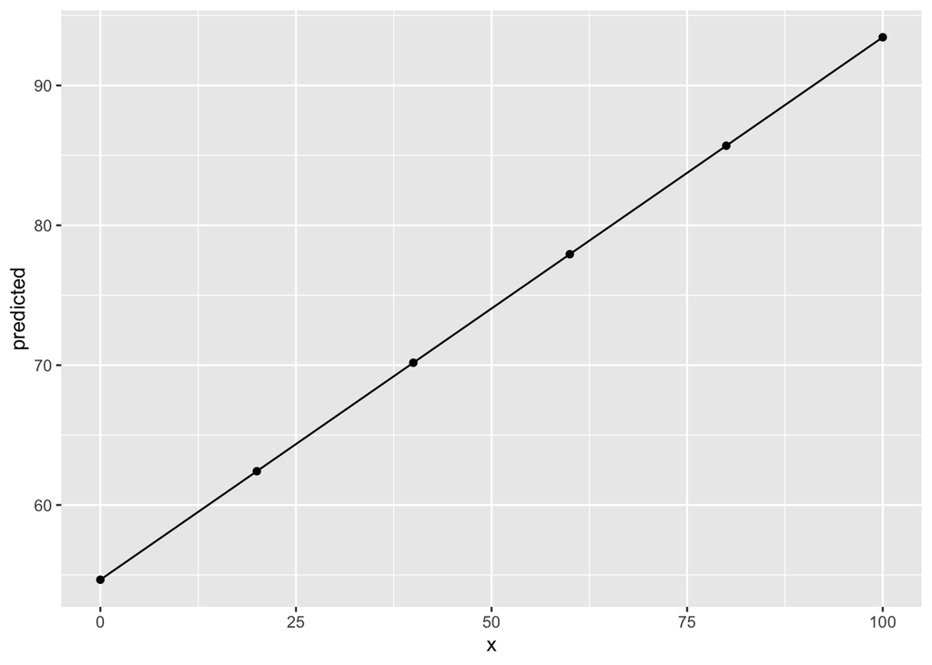

```r
library(ggplot2)
mydf <- ggpredict(modelo2, terms = "TASA_INDIGENA")
ggplot(mydf, aes(x, predicted)) + geom_line() + geom_point()
```

Comparando predictores para saber cuál impacta más en el voto:

```r
library(lm.beta)
lm.beta(modelo2)
```

```
##
## Call:
## lm(formula = PORC_PL ~ TASA_INDIGENA + DESNUTRICION + DISC_2020_PORC +
##     POBREZA + GASTO, data = data)
##
## Standardized Coefficients::
##    (Intercept)  TASA_INDIGENA   DESNUTRICION DISC_2020_PORC        POBREZA
##    0.000000000    0.589590874   -0.019005130    0.007642652    0.334709787
##          GASTO
##    0.002624012
```

Podemos estandarizar, también, los predictores, pero dejar como tal la variable de respuesta:

```r
modelo3 = lm(PORC_PL ~ scale(TASA_INDIGENA) + scale(DESNUTRICION) + scale(DISC_2020_PORC) + scale(POBREZA) + scale(GASTO),
             data = data)
summary(modelo3)
```

```
##
## Call:
## lm(formula = PORC_PL ~ scale(TASA_INDIGENA) + scale(DESNUTRICION) +
##     scale(DISC_2020_PORC) + scale(POBREZA) + scale(GASTO), data = data)
##
## Residuals:
##     Min      1Q  Median      3Q     Max
## -57.865  -7.543   1.157   8.532  37.692
##
## Coefficients:
##                       Estimate Std. Error t value Pr(>|t|)
## (Intercept)           67.44429    0.31624 213.270   <2e-16 ***
## scale(TASA_INDIGENA)  11.28145    0.32529  34.681   <2e-16 ***
## scale(DESNUTRICION)   -0.37047    0.38604  -0.960    0.337
## scale(DISC_2020_PORC)  0.14673    0.31745   0.462    0.644
## scale(POBREZA)         6.35120    0.38472  16.509   <2e-16 ***
## scale(GASTO)           0.04982    0.31590   0.158    0.875
## ---
## Signif. codes:  0 '***' 0.001 '**' 0.01 '*' 0.05 '.' 0.1 ' ' 1
##
## Residual standard error: 13 on 1685 degrees of freedom
##   (183 observations deleted due to missingness)
## Multiple R-squared:  0.5441, Adjusted R-squared:  0.5427
## F-statistic: 402.2 on 5 and 1685 DF,  p-value: < 2.2e-16
```

Así:

- El aumento de una desviación estandar en el % de personas que se autoidentifican como indígenas aumenta el % de voto por PL a nivel distrital en 11.28%.